# BayesianAnalysisForPrereg

Alex Holcombe

2/27/2018

Illustrate the Bayesian analysis to be done, using the results from E1 as a dummy dataset and showing how the prior is informed by the results of our previous experiments.

Read in parameter estimates

```r
estimates<- read.csv(file="../../E1/Results/backwards2E1_paramEstimates.csv", header=TRUE, sep=",")
estimates$X<- NULL #Not sure where X came from but it's just a row number
```

Exclude Ss who failed likelihood ratio test in all four cases. Create new column nPassed for in how many conditions they passed (out of 4).

```r
library(dplyr)
estimates<- estimates %>% mutate(mixModelFitsBetter = pLRtest<.05)

condtnVariableNames <- c("subject","stream", "orientation")

e<- estimates %>%  group_by(subject) %>%
  summarise(nPassed = sum(mixModelFitsBetter))
estimates<- merge(e,estimates)

estimates<- estimates %>% mutate( exclude = (nPassed==0)  )
```

Assess the size of the effect to inform Bayesian test of next experiment (originally tried this with raw units, but then realized that makes the stats difficult, I forget why)

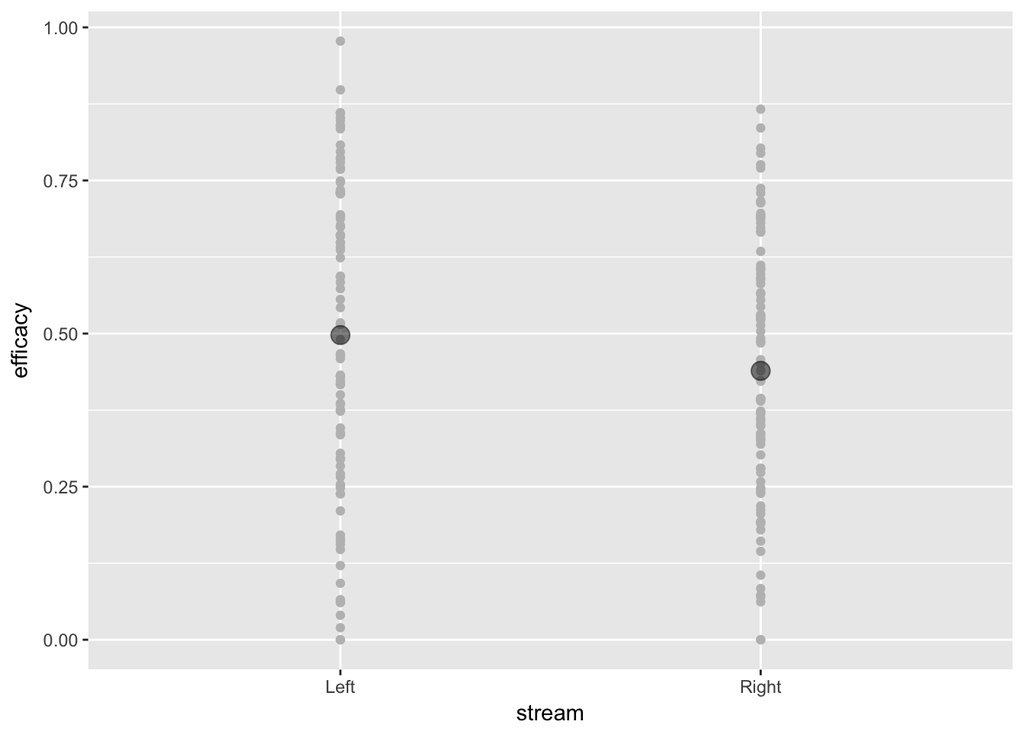

```
##   orientation subject nPassed      Left      Right       dv
## 1   Canonical      AA       4 0.8394000 0.52699269 efficacy
## 2   Canonical      AB       4 0.8481378 0.36901496 efficacy
## 3   Canonical      AC       4 0.5925631 0.27289386 efficacy
## 4   Canonical      AD       4 0.5423585 0.18948088 efficacy
## 5   Canonical      AE       4 0.8596327 0.39343229 efficacy
## 6   Canonical      AF       0 0.0608706 0.07001129 efficacy
```

Calculate bias

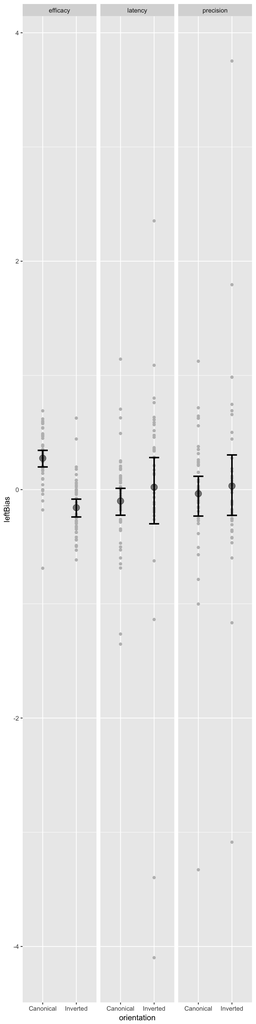

```r
allP2E1$leftBias<- allP2E1$Left - allP2E1$Right
hh<-ggplot(allP2E1, aes(x=orientation, y=leftBias)) + facet_grid(.~dv) + geom_point(color="grey") + stat_summary(fun.y="mean",geom="point",size=4, alpha=.5)
hh<-hh+stat_summary(fun.data="mean_cl_boot",geom="errorbar",width=.3,conf.int=.95,
                  width=5,size=1)
show(hh)
```

Print effect size

```r
leftBiasesCanonical<- filter(allP2E1,dv=="efficacy" & orientation=="Canonical")$leftBias
leftBiasCanonical <- mean( leftBiasesCanonical )
leftBiasesInverted<- filter(allP2E1,dv=="efficacy" & orientation=="Inverted")$leftBias
leftBiasInverted<- mean(   leftBiasesInverted  )
leftBiasDiff<- leftBiasCanonical - leftBiasInverted
leftBias_sd <- sd(   leftBiasesCanonical - leftBiasesInverted )
```

The leftBiasDiff for this experiment is 0.4328182 or in Cohen’s d 0.8946052, very healthy.

What was it for the first paper? For E1,0.23 Canonical and 0.062 Mirror-reversed. Difference is 0.168 . For E2, bias difference very similar at 0.201. For E2 vertical arrangement, 0.258

Do conventional stats on P2E1 efficacy leftBias.

```r
require(ez)
aa <- ezANOVA(data=filter(allP2E1,dv=="efficacy"), dv=leftBias, within=orientation, wid=subject)
cat("F=", aa$ANOVA$F, " p=", aa$ANOVA$p, "\n", sep="")
```

```
## F=36.01433 p=3.361079e-07
```

Do Bayesian t-test. That is, take the likelihood of the left bias difference observed under the prior and divide it by the likelihood of the left bias difference observed under the null.

http://jeffrouder.blogspot.com.au/2016/01/what-priors-should-i-use-part-i.html For the null model, the bias is just zero (delta function).For our model, support is zero to infinity.

First, a quick look at it with a custom prior in raw units.

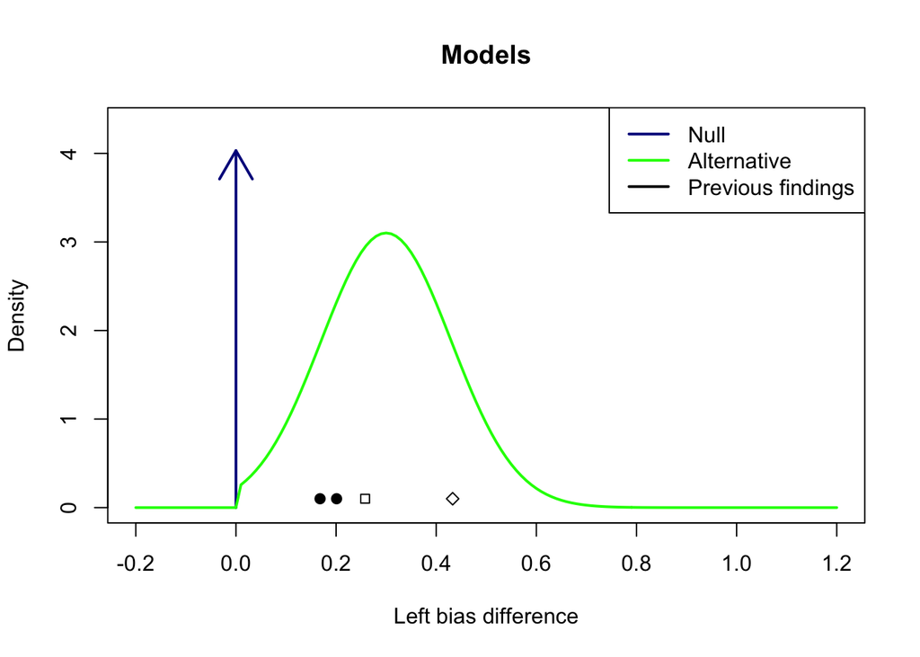

```r
#Specify alternative hypothesis (prior)

#Specify Alternative (up to constant of proportionality)
lo=0 #lower bound of support
hi=Inf #upper bound of support
altDens=function(delta) {
  y= dnorm(delta,.3,.13)
  y=y*as.integer(delta>lo)*as.integer(delta<hi) #multiply by zero if outside of support
}

#Normalize alternative density in case user does not,
K=1/integrate(altDens,lower=lo,upper=hi)$value
f=function(delta) K*altDens(delta)

delta=seq(-.2,1.2,.01)

#Plot Alternative as a density and Null as a point arrow
maxAlt=max(f(delta))
plot(delta,f(delta),typ='n',xlab="Left bias difference",ylab="Density",ylim=c(0,1.4*maxAlt),main="Models")
arrows(0,0,0,1.3*maxAlt,col='darkblue',lwd=2)
lines(delta,f(delta),col='green',lwd=2)
legend("topright",legend=c("Null","Alternative","Previous findings"),col=c('darkblue','green','black'),lwd=2)

points(P1E1leftBiasDiff,.1,pch=19)
points(P1E2leftBiasDiff,.1,pch=19)
points(P1E2vertBiasDiff,.1,pch=22)
points(leftBiasDiff,.1,pch=23)
```

Probably better to do it in standardized units (Cohen’s d) because otherwise need to create a model of the variance separately (for the data model) so that can calculate the probability of the data given e.g. the null hypothesis.

```r
P2E1_cohensD <- leftBiasDiff / leftBias_sd
cohensDs<-c(P1E1leftBiasDiff / P1E1diff_sd,
            P1E2leftBiasDiff / P1E2diff_sd,
            P1E2vertBiasDiff / P1E2vdiff_sd,
            P2E1_cohensD )
print(cohensDs)
```

```
## [1] 0.4898979 1.0797093 1.1205113 0.8946052
```

```r
labels<-c("P1E1","P1E2","P1E2v","P2E1")
meanCohensD<- mean(cohensDs)
```

Our informed prior will be a Gaussian distribution with mean our mean observed effect (as a Cohen’s d), 0.8961809 and sigma 0.2881407.

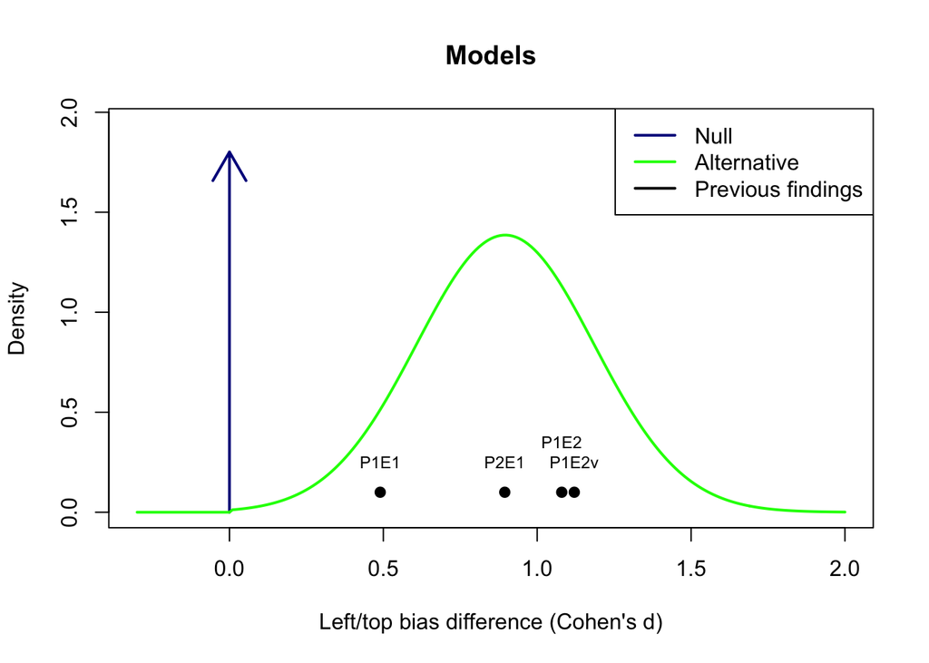

```r
#Specify Alternative (up to constant of proportionality)
lo=0 #lower bound of support
hi=Inf #upper bound of support

altHypothesisPrior=function(delta) {
  mean= meanCohensD
  sigma= sd(cohensDs)
  y= dnorm(delta,mean,sigma)
  y=y*as.integer(delta>lo)*as.integer(delta<hi) #multiply by zero if outside of support
}
#Normalize alternative density in case is not already
K=1/integrate(altHypothesisPrior,lower=lo,upper=hi)$value
prior=function(delta) K*altHypothesisPrior(delta)

dDomain=seq(-.3,2,.01)

#Plot Alternative as a density and Null as a point arrow
maxAlt=max(prior(delta))
plot(dDomain,prior(dDomain),typ='n',xlab="Left/top bias difference (Cohen's d)",ylab="Density",ylim=c(0,1.4*maxAlt),main="Models")
arrows(0,0,0,1.3*maxAlt,col='darkblue',lwd=2)
lines(dDomain,prior(dDomain),col='green',lwd=2)
legend("topright",legend=c("Null","Alternative","Previous findings"),col=c('darkblue','green','black'),lwd=2)

points(cohensDs, rep(.1,4),pch=19) #plot previous effect sizes
text(cohensDs, c(.25,.35,.25,.25), labels,cex=.75)
```

To be honest it is hard to know how to set the sigma (width of the prior in the above graph) because how much to think of the previous estimates as estimating the same thing versus being actually different effects? Setting it to the sd of the previous results looks reasonable.

To calculate Bayes factors, first generate the probability of any particular result according to the null hypothesis and according to the alternative hypothesis. For the alternative, integrate over the whole prior distribution of effect sizes, weighting by the prior.

Let’s say we have a sample size of 50.

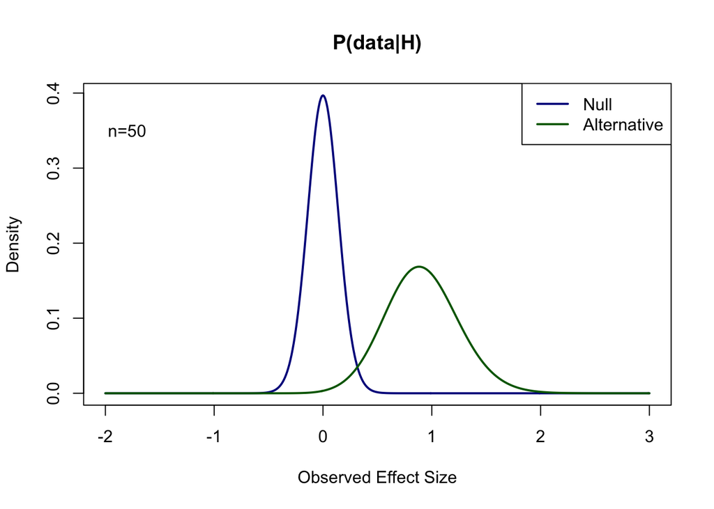

```r
#The predicted density of data for the null is below; it's related to the central t distribution.
nullPredF=function(obs,N) dt(sqrt(N)*obs,N-1)

#compute the probability of the data (predicted density) for any observed effect size or for all of them. The following code does it for a reasonable range of effect sizes for a sample size of 30. You can change N, the sample size, as needed.
obsEffectSizes=seq(-2,3,.01) #a list of thousands of possible Cohen's ds we might observe
N=50
nullPred=nullPredF(obsEffectSizes,N)
#nullPred is the height of the density function under the null hypothesis at each cohen's d obsEffectSize

#Getting the probabilites of the data for the alternative is a bit harder. For each nonzero effect size parameter, the distribution of the observed effect follows a noncentral t distribution. Hence, to obtain predictions across all nonzero effect sizes, we need to integrate the alternative model (with, in the prior, its different height in the density for each possible effect size) against the noncentral t distribution.

altPredIntegrand=function(delta,obs,N) {
  #call the student-t distribution, with delta the effect size
  dt(sqrt(N)*obs,N-1,sqrt(N)*delta)*prior(delta)
}

altPredF=function(obs,N) {
  #integrate delta from lo to hi, for one particular possible observed effect size. Because calculating the
  # probability of the observed effect size for each imagined true effect size.
  suppressWarnings( integrate(altPredIntegrand,lower=lo,upper=hi,obs=obs,N=N)$value
  )
}

#For each observed effect size, compute density of the alternative - essentially the probability of that
#outcome according to the alternative hypothesis.
I=length(obsEffectSizes)
altPred=1:I
for (i in 1:I) {
  altPred[i] = altPredF(obsEffectSizes[i],N)
}

#Now we can plot the predictions for all observed effect sizes:
top=max(altPred,nullPred)

plot(type='l',obsEffectSizes,nullPred,ylim=c(0,top),xlab="Observed Effect Size",ylab="Density",main="P(data|H)",col='darkblue',lwd=2)
lines(obsEffectSizes,altPred,col='darkgreen',lwd=2)
legend("topright",legend=c("Null","Alternative"),col=c('darkblue','darkgreen'),lwd=2)
text(-1.8,.35,"n=50")
```

BTW get this warning: https://stackoverflow.com/questions/39183938/rs-t-distribution-says-full-precision-may-not-have-been-achieved

```r
smaller=.3333
my.es= meanCohensD * smaller
my.sd = sd(cohensDs) * 1.5
```

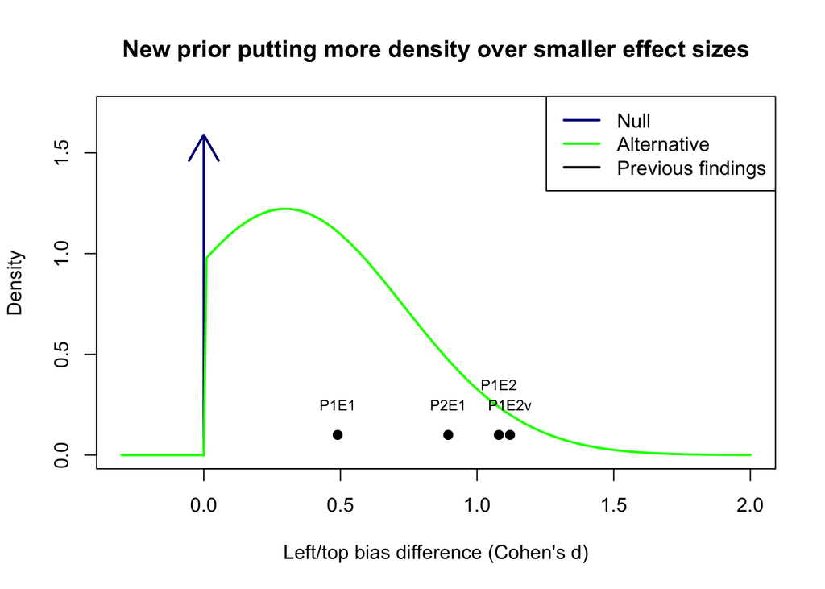

```r
altPrior=function(delta) {
  mean= my.es
  sigma= my.sd
  y= dnorm(delta,mean,sigma)
  y=y*as.integer(delta>lo)*as.integer(delta<hi) #multiply by zero if outside of support
}

#Normalize alternative density in case user does not,
K=1/integrate(altPrior,lower=lo,upper=hi)$value
altPriorNormalized=function(delta) K*altPrior(delta)


#Plot this new smaller-effect prior
dDomain=seq(-.3,2,.01)

#Plot Alternative as a density and Null as a point arrow
maxAlt=max(altPriorNormalized(delta))
plot(dDomain,altPriorNormalized(dDomain),typ='n',xlab="Left/top bias difference (Cohen's d)",ylab="Density",ylim=c(0,1.4*maxAlt),main="New prior putting more density over smaller effect sizes")
arrows(0,0,0,1.3*maxAlt,col='darkblue',lwd=2)
lines(dDomain,altPriorNormalized(dDomain),col='green',lwd=2)
legend("topright",legend=c("Null","Alternative","Previous findings"),col=c('darkblue','green','black'),lwd=2)

points(cohensDs, rep(.1,4),pch=19) #plot previous effect sizes
text(cohensDs, c(.25,.35,.25,.25), labels,cex=.75)
```

```r
N=75
```

Now visualize likelihoods for N=75

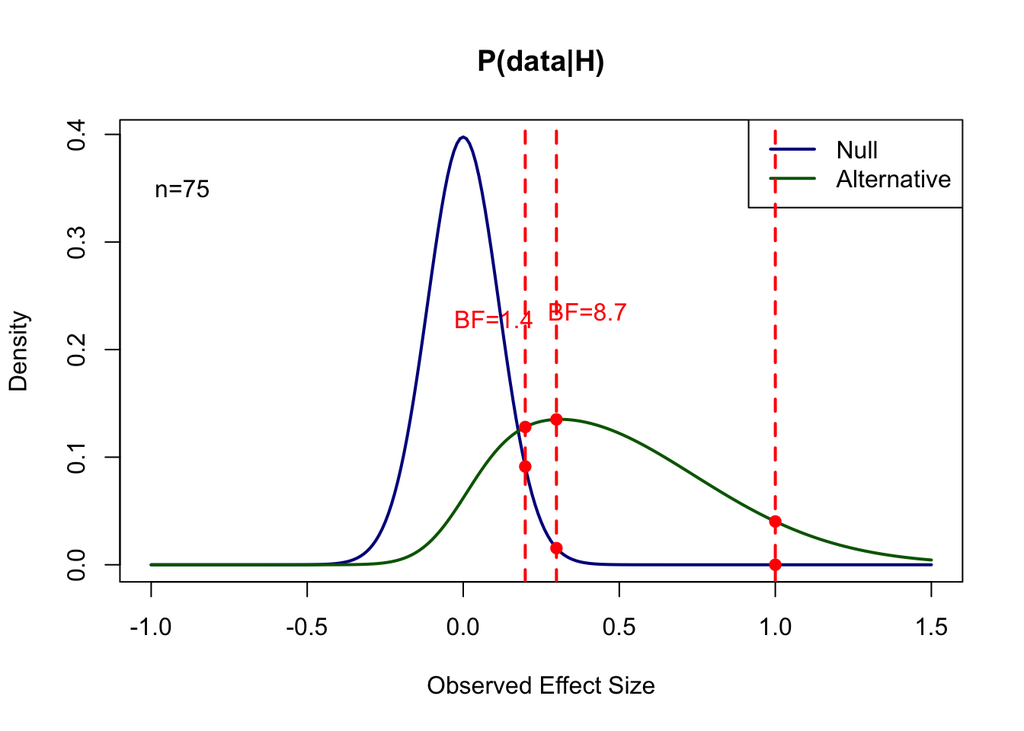

```r
# to obtain predictions across all nonzero effect sizeS, we need to integrate the alternative model against the noncentral t distribution. Here is the code with a simple loop:

altPredIntegrand=function(delta,obs,N) {
  dt(sqrt(N)*obs,N-1,sqrt(N)*delta)*altPriorNormalized(delta)
}

altPredF=function(obs,N) {
  suppressWarnings( integrate(altPredIntegrand,lower=lo,upper=hi,obs=obs,N=N)$value
  )
}

#For each effect size, compute density
obsEffectSizes=seq(-1,1.5,.01)

I=length(obsEffectSizes)
altPred=1:I
for (i in 1:I) {
  altPred[i] = altPredF(obsEffectSizes[i],N)
}

nullPred=nullPredF(obsEffectSizes,N)

#Now we can plot the predictions for all observed effect sizes:
top=max(altPred,nullPred)

plot(type='l',obsEffectSizes,nullPred,ylim=c(0,top),xlab="Observed Effect Size",ylab="Density",main="P(data|H)",col='darkblue',lwd=2)
lines(obsEffectSizes,altPred,col='darkgreen',lwd=2)
legend("topright",legend=c("Null","Alternative"),col=c('darkblue','darkgreen'),lwd=2)
text(-.9,.35,paste0("n=",N))
#plot example small effect size point on curve
abline(v=my.es,lty=2,lwd=2,col='red')
valNull=nullPredF(my.es,N)
valAlt=altPredF(my.es,N)
points(pch=19,c(my.es,my.es),c(valNull,valAlt),col="red")
text(my.es+.1,valAlt+.1,paste0("BF=",round(valAlt/valNull,1)),col="red")

#plot example even smaller effect size points on curve
abline(v=my.es-.1,lty=2,lwd=2,col='red')
valNull=nullPredF(my.es-.1,N)
valAlt=altPredF(my.es-.1,N)
points(pch=19,c(my.es-.1,my.es-.1),c(valNull,valAlt),col="red")
text(my.es-.2,valAlt+.1,paste0("BF=",round(valAlt/valNull,1)),col="red")

#plot example large effect size points on curve
large.es<-1
abline(v=large.es,lty=2,lwd=2,col='red')
valNull=nullPredF(large.es,N)
valAlt=altPredF(large.es,N)
points(pch=19,c(large.es,large.es),c(valNull,valAlt),col="red")
text(large.es+.3,valAlt-.1,paste0("BF=",round(valAlt/valNull,1)),col="red")
```

And for n=100

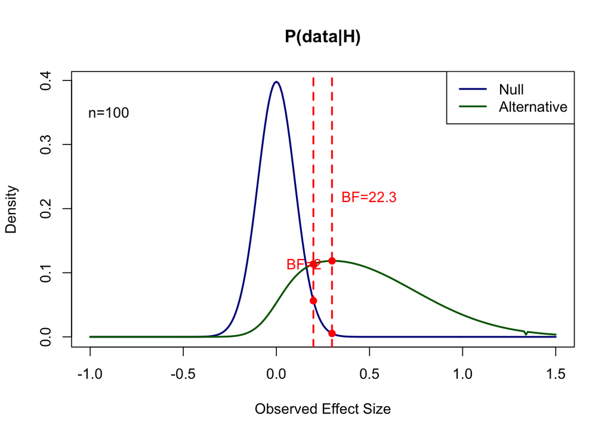

So in summary, the above two graphs with associated blocks of code show how the Bayes factor will be calculated for whatever observed effect size turns up, and is thus suitable for citing in the prereg document. To boil it down, the prior we’ll be using is simply a Gaussian truncated at zero (bright green curve several plots ago with mean Cohen’s d = 0.2986971 and sigma = 0.432211 but it does mean that even with n=100, an observed effect size of 0.2 means the evidence is very ambiguous (Bayes factor close to 1, specifically 2 )

To do a true Bayesian power analysis, could follow Lakens here: https://daniellakens.blogspot.com.au/2016/01/power-analysis-for-default-bayesian-t.html